# Monte Carlo Applied to Infectious Airborne Diseases

## Article

Beggs. et al., a study conducted to understand the harm infectious people bring to healthcare waiting rooms. Their hope was to to have findings that backed up the idea to have more precautions to minimize the spread of airborne infections. The diseases they looked at were Tuberculosis, Measles, and Influenza. We followed a Stochastic Monte Carlo Model to simulate the probability of a susceptible person catching the listed airborne disease.

## Assumptions

Assumptions made:

- Only one infectious individual present in each simulation
- Waiting room is ventilated w outside air at a constant flow rate
- Air in waiting room is mixed so infectious particles are evenly distributed throughout the room space.
- Values of p, phi, t, and S vary and are normally distributed.
- Once susceptible individuals become infected they cannot infect anyone else

## Equation:

\[ P = 1 - \exp \Bigg[ - \frac{p \, I \, \phi}{V} \cdot \frac{N t + e^(-N t) - 1}{N^2} \Bigg] \]

- P –> probability of infection of susceptible individuals
- p –> pulmonary ventilation rate
- I –> # of infectors
- \(\phi\) –> quantum generation rate (quanta/hr)
- V –> room volume
- N –> room ventilation rate (air change/hr)
- t –> exposure time for susceptible individuals (h)

## Quanta Rate:

First defined by Wells (1955), he built a model for airborne infections with goal to quantify the amount of infectious material needed to cause infection.

“Quantum” - the amount of airborne material required to infect a majority of susceptible individuals exposed to it (the infectious dose) 1 quantum inhaled means the probability of infection to be 63.2%

## Original Findings VS Our Replication:

[output not shown]

## Replication

```
## TB Probability: 0.003677658
```

```
## Influenza Probability: 0.02629693
```

```
## Measles Probability: 0.1360328
```

We had 2 main goals going into this project:

- we wanted to observe probability of infection as we changed some of Beggs et al. set variables such as room volume, number of ppl infected, and exposure time
- we wanted to replicate their Monte Carlo approach and apply it to a different disease (SARS)

## Scenario 1

For the first scenario, the factors we set/changed were:

- room size: we increased the size to 300 cubic meters
- exposure time: increased by 30 seconds (1 minute in total).
- infected: only one infected person in the room.

### Prediction: the infection probability would decrease.

## Scenario 1 Results

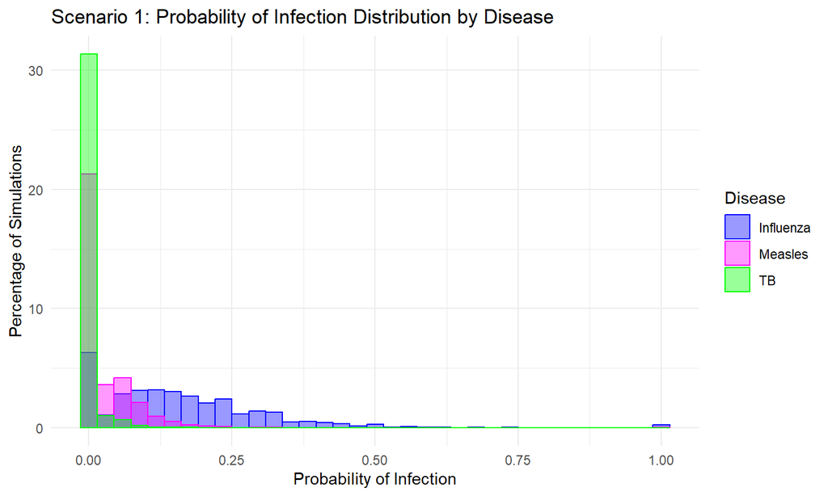

## Scenario 2

The room volume was smaller (50m^3 opposed to 132m^2). The exposure time is the same as the article at 30 minutes. There are now two infected people in the room. Before hand, we predicted that the infection probability would increase.

### Prediction: the infection probability would increase

## Scenario 2 Results

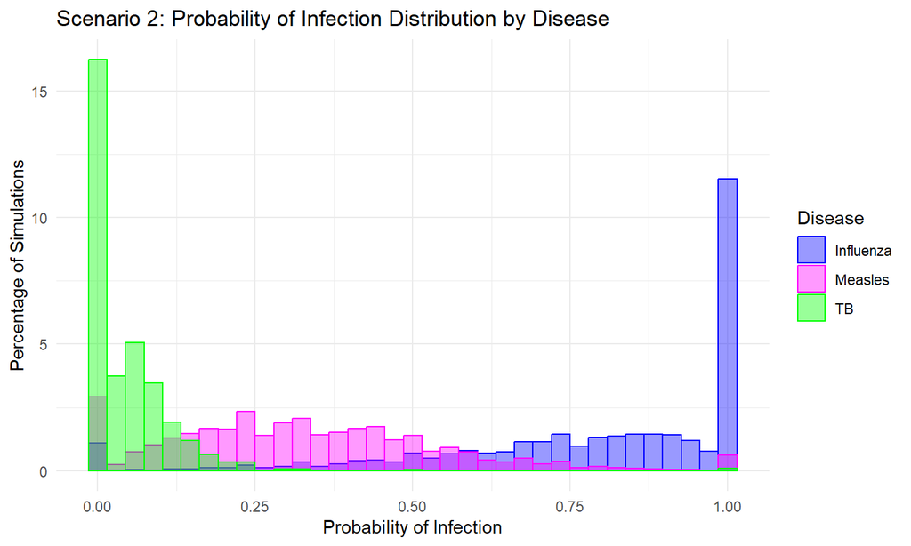

## New Disease

The disease we wanted to test everything with was SARS.Severe Acute Respiratory Syndrome, or SARS, is a common respiratory illness that is also typically spread through the air as well as being is close contact with an infected person.

-The SARS quanta was: 2.7 with a standev of 1.2

## New Disease Results

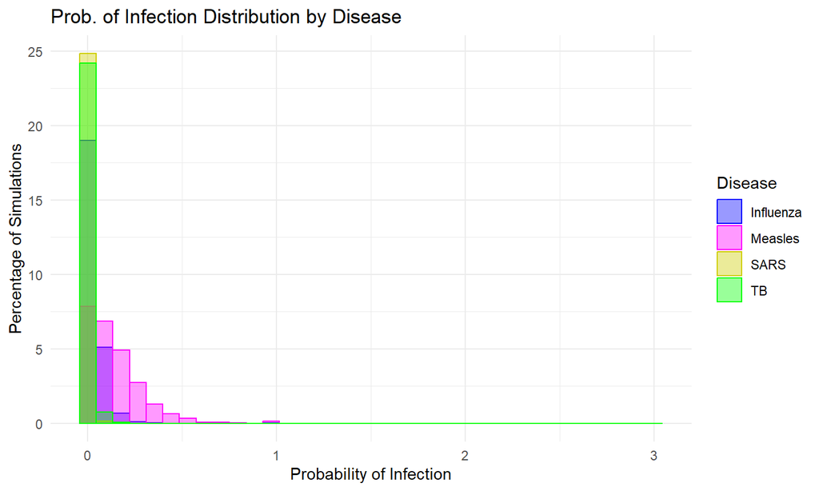

## Conclusion

A higher quanta rate is more likely to increase the probability of susceptible people contracting the airborn disease.